# Kolins_M_Final_Project_Done

M. Kolins "On my honor, as a student, I have neither given nor received unauthorized aid on this academic work."

```python
from IPython.display import YouTubeVideo
YouTubeVideo('Y7xjCZwhywA')
```

[video not shown]

## Problem Statement

The purpose of this project is to find and develop a model for accurate future predictive analysis. This analysis will help future consumers understand what drives a IMDB score and what future movies will score.

# Import Data

```python
import pandas as pd
import numpy as np
import seaborn as sns
from scipy import stats
import matplotlib.pyplot as plt
%matplotlib inline

# import the scatter_matrix functionality
from pandas.plotting import scatter_matrix

import pingouin as pg
```

```python
import pandas as pd
import numpy as np
import seaborn as sns
import matplotlib.pyplot as plt
%matplotlib inline

#regression packages
import sklearn.linear_model as lm
from sklearn.metrics import mean_squared_error
from sklearn.metrics import explained_variance_score

#lasso regression
from sklearn import linear_model

#f_regression (feature selection)
from sklearn.feature_selection import f_regression
from sklearn.feature_selection import SelectKBest

# recursive feature selection (feature selection)
from sklearn.feature_selection import RFE

import statsmodels.api as sm
from statsmodels.formula.api import ols
```

```python
import numpy as np
import pandas as pd
import matplotlib.pyplot as plt
import seaborn as sns
%matplotlib inline

#import decisiontreeclassifier
from sklearn import tree
from sklearn.tree import DecisionTreeClassifier, export_graphviz
from IPython.display import SVG
#from graphviz import Source
from IPython.display import display
#import logisticregression classifier
from sklearn.linear_model import LogisticRegression
import statsmodels.api as sm
#import knn classifier
from sklearn.neighbors import KNeighborsClassifier

#for validating your classification model
from sklearn.metrics import classification_report, f1_score, accuracy_score, confusion_matrix
from sklearn.model_selection import StratifiedKFold, cross_val_score, train_test_split, GridSearchCV
from sklearn import metrics
from sklearn.metrics import roc_curve, auc

# feature selection
from sklearn.feature_selection import RFE
from sklearn.ensemble import ExtraTreesClassifier
from sklearn.feature_selection import SelectKBest
from sklearn.feature_selection import chi2

#pip install scikit-plot (optional)
import scikitplot as skplt

import warnings
warnings.filterwarnings("ignore")
```

```python
import numpy as np
import pandas as pd
import matplotlib.pyplot as plt
import seaborn as sns
%matplotlib inline

#for validating your classification model
from sklearn.model_selection import train_test_split
from sklearn.model_selection import cross_val_score
from sklearn import metrics
from sklearn.metrics import roc_curve, auc
from sklearn.metrics import roc_auc_score

# advanced algorthms
from sklearn.neural_network import MLPClassifier
from sklearn.ensemble import GradientBoostingClassifier
from sklearn.svm import SVC
```

```python
import pandas as pd
import numpy as np
import matplotlib.pyplot as plt
import seaborn as sns
%matplotlib inline

from sklearn.cluster import KMeans

from sklearn.cluster import AgglomerativeClustering
from sklearn.metrics import pairwise_distances
```

```python
import pandas as pd
import numpy as np
import matplotlib.pyplot as plt
import seaborn as sns
%matplotlib inline

from sklearn.cluster import KMeans
from sklearn.cluster import AgglomerativeClustering
from sklearn.cluster import ward_tree
from scipy.cluster.hierarchy import dendrogram, linkage, ward

from sklearn.metrics import pairwise_distances
```

```python
import pandas as pd
import numpy as np
import matplotlib.pyplot as plt
import seaborn as sns
%matplotlib inline

from sklearn.cluster import KMeans
from sklearn.cluster import AgglomerativeClustering
from sklearn.cluster import ward_tree
from scipy.cluster.hierarchy import dendrogram, linkage, ward

from sklearn.metrics import pairwise_distances

pd.set_option('display.float_format', lambda x: '%.3f' % x)
```

# Data Understanding

## Load Data

```python
df=pd.read_csv('movie.csv')
df.head()
```

|  | color | director_name | num_critic_for_reviews | duration | director_facebook_likes | actor_3_facebook_likes | actor_2_name | actor_1_facebook_likes | gross | genres | actor_1_name | movie_title | num_voted_users | cast_total_facebook_likes | actor_3_name | facenumber_in_poster | plot_keywords | movie_imdb_link | num_user_for_reviews | language | country | content_rating | budget | title_year | actor_2_facebook_likes | imdb_score | aspect_ratio | movie_facebook_likes |
| --- | --- | --- | --- | --- | --- | --- | --- | --- | --- | --- | --- | --- | --- | --- | --- | --- | --- | --- | --- | --- | --- | --- | --- | --- | --- | --- | --- | --- |
| 0 | Color | James Cameron | 723.000 | 178.000 | 0.000 | 855.000 | Joel David Moore | 1000.000 | 760505847.000 | Action\|Adventure\|Fantasy\|Sci-Fi | CCH Pounder | Avatar | 886204 | 4834 | Wes Studi | 0.000 | avatar\|future\|marine\|native\|paraplegic | http://www.imdb.com/title/tt0499549/?ref_=fn_tt_tt_1 | 3054.000 | English | USA | PG-13 | 237000000.000 | 2009.000 | 936.000 | 7.900 | 1.780 | 33000 |
| 1 | Color | Gore Verbinski | 302.000 | 169.000 | 563.000 | 1000.000 | Orlando Bloom | 40000.000 | 309404152.000 | Action\|Adventure\|Fantasy | Johnny Depp | Pirates of the Caribbean: At World's End | 471220 | 48350 | Jack Davenport | 0.000 | goddess\|marriage ceremony\|marriage proposal\|pirate\|singapore | http://www.imdb.com/title/tt0449088/?ref_=fn_tt_tt_1 | 1238.000 | English | USA | PG-13 | 300000000.000 | 2007.000 | 5000.000 | 7.100 | 2.350 | 0 |
| 2 | Color | Sam Mendes | 602.000 | 148.000 | 0.000 | 161.000 | Rory Kinnear | 11000.000 | 200074175.000 | Action\|Adventure\|Thriller | Christoph Waltz | Spectre | 275868 | 11700 | Stephanie Sigman | 1.000 | bomb\|espionage\|sequel\|spy\|terrorist | http://www.imdb.com/title/tt2379713/?ref_=fn_tt_tt_1 | 994.000 | English | UK | PG-13 | 245000000.000 | 2015.000 | 393.000 | 6.800 | 2.350 | 85000 |
| 3 | Color | Christopher Nolan | 813.000 | 164.000 | 22000.000 | 23000.000 | Christian Bale | 27000.000 | 448130642.000 | Action\|Thriller | Tom Hardy | The Dark Knight Rises | 1144337 | 106759 | Joseph Gordon-Levitt | 0.000 | deception\|imprisonment\|lawlessness\|police officer\|terrorist plot | http://www.imdb.com/title/tt1345836/?ref_=fn_tt_tt_1 | 2701.000 | English | USA | PG-13 | 250000000.000 | 2012.000 | 23000.000 | 8.500 | 2.350 | 164000 |
| 4 | NaN | Doug Walker | nan | nan | 131.000 | nan | Rob Walker | 131.000 | nan | Documentary | Doug Walker | Star Wars: Episode VII - The Force Awakens | 8 | 143 | NaN | 0.000 | NaN | http://www.imdb.com/title/tt5289954/?ref_=fn_tt_tt_1 | nan | NaN | NaN | NaN | nan | nan | 12.000 | 7.100 | nan | 0 |

Display of the imported data

### Data Info

```python
df.info()
```

```
<class 'pandas.core.frame.DataFrame'>
RangeIndex: 5043 entries, 0 to 5042
Data columns (total 28 columns):
color                        5024 non-null object
director_name                4939 non-null object
num_critic_for_reviews       4993 non-null float64
duration                     5028 non-null float64
director_facebook_likes      4939 non-null float64
actor_3_facebook_likes       5020 non-null float64
actor_2_name                 5030 non-null object
actor_1_facebook_likes       5036 non-null float64
gross                        4159 non-null float64
genres                       5043 non-null object
actor_1_name                 5036 non-null object
movie_title                  5043 non-null object
num_voted_users              5043 non-null int64
cast_total_facebook_likes    5043 non-null int64
actor_3_name                 5020 non-null object
facenumber_in_poster         5030 non-null float64
plot_keywords                4890 non-null object
movie_imdb_link              5043 non-null object
num_user_for_reviews         5022 non-null float64
language                     5031 non-null object
country                      5038 non-null object
content_rating               4740 non-null object
budget                       4551 non-null float64
title_year                   4935 non-null float64
actor_2_facebook_likes       5030 non-null float64
imdb_score                   5043 non-null float64
aspect_ratio                 4714 non-null float64
movie_facebook_likes         5043 non-null int64
dtypes: float64(13), int64(3), object(12)
memory usage: 1.1+ MB
```

Information on the data to help in the ETL process

### Data Statistics

```python
df.describe()
```

|  | num_critic_for_reviews | duration | director_facebook_likes | actor_3_facebook_likes | actor_1_facebook_likes | gross | num_voted_users | cast_total_facebook_likes | facenumber_in_poster | num_user_for_reviews | budget | title_year | actor_2_facebook_likes | imdb_score | aspect_ratio | movie_facebook_likes |
| --- | --- | --- | --- | --- | --- | --- | --- | --- | --- | --- | --- | --- | --- | --- | --- | --- |
| count | 4993.000 | 5028.000 | 4939.000 | 5020.000 | 5036.000 | 4159.000 | 5043.000 | 5043.000 | 5030.000 | 5022.000 | 4551.000 | 4935.000 | 5030.000 | 5043.000 | 4714.000 | 5043.000 |
| mean | 140.194 | 107.201 | 686.509 | 645.010 | 6560.047 | 48468407.527 | 83668.161 | 9699.064 | 1.371 | 272.771 | 39752620.436 | 2002.471 | 1651.754 | 6.442 | 2.220 | 7525.965 |
| std | 121.602 | 25.197 | 2813.329 | 1665.042 | 15020.759 | 68452990.439 | 138485.257 | 18163.799 | 2.014 | 377.983 | 206114898.449 | 12.475 | 4042.439 | 1.125 | 1.385 | 19320.445 |
| min | 1.000 | 7.000 | 0.000 | 0.000 | 0.000 | 162.000 | 5.000 | 0.000 | 0.000 | 1.000 | 218.000 | 1916.000 | 0.000 | 1.600 | 1.180 | 0.000 |
| 25% | 50.000 | 93.000 | 7.000 | 133.000 | 614.000 | 5340987.500 | 8593.500 | 1411.000 | 0.000 | 65.000 | 6000000.000 | 1999.000 | 281.000 | 5.800 | 1.850 | 0.000 |
| 50% | 110.000 | 103.000 | 49.000 | 371.500 | 988.000 | 25517500.000 | 34359.000 | 3090.000 | 1.000 | 156.000 | 20000000.000 | 2005.000 | 595.000 | 6.600 | 2.350 | 166.000 |
| 75% | 195.000 | 118.000 | 194.500 | 636.000 | 11000.000 | 62309437.500 | 96309.000 | 13756.500 | 2.000 | 326.000 | 45000000.000 | 2011.000 | 918.000 | 7.200 | 2.350 | 3000.000 |
| max | 813.000 | 511.000 | 23000.000 | 23000.000 | 640000.000 | 760505847.000 | 1689764.000 | 656730.000 | 43.000 | 5060.000 | 12215500000.000 | 2016.000 | 137000.000 | 9.500 | 16.000 | 349000.000 |

Information on the data to help in the ETL process

### Quality Issues

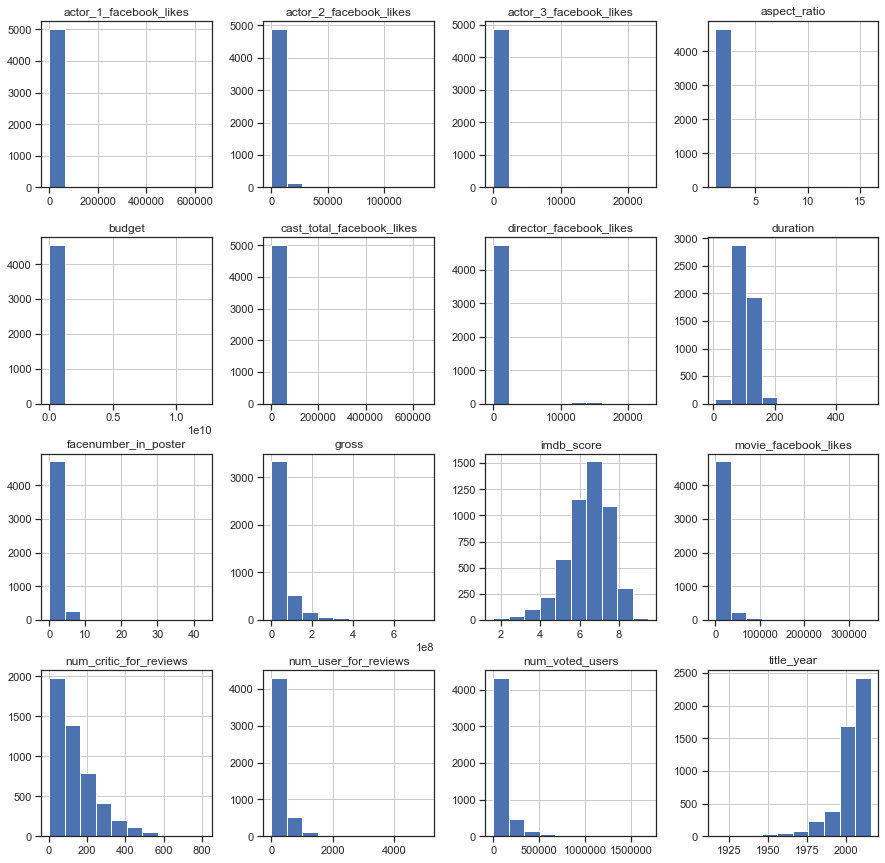

```python
df.hist(figsize=(15,15));
```

Information on the data to help in the ETL process

### Find Null Values

```python
df.isnull().sum()
```

```
color                        19
director_name                104
num_critic_for_reviews       50
duration                     15
director_facebook_likes      104
actor_3_facebook_likes       23
actor_2_name                 13
actor_1_facebook_likes       7
gross                        884
genres                       0
actor_1_name                 7
movie_title                  0
num_voted_users              0
cast_total_facebook_likes    0
actor_3_name                 23
facenumber_in_poster         13
plot_keywords                153
movie_imdb_link              0
num_user_for_reviews         21
language                     12
country                      5
content_rating               303
budget                       492
title_year                   108
actor_2_facebook_likes       13
imdb_score                   0
aspect_ratio                 329
movie_facebook_likes         0
dtype: int64
```

Information on the data to help in the ETL process

# Data Cleaning

## Remove Duplicates

Below I am removing the 45 duplicates found

```python
len(df)
```

```
5043
```

```python
len(df[df.duplicated(keep='first')])
```

```
45
```

```python
df = df.drop_duplicates(keep='first')
len(df)
```

```
4998
```

## Remove Columns

Movie Link is Irrelavant - Drop

### Movie Link

```python
df = df.drop('movie_imdb_link', axis=1)
```

### Language

```python
df.groupby('language').size()
```

```
language
Aboriginal    2
Arabic        5
Aramaic       1
Bosnian       1
Cantonese     11
Chinese       3
Czech         1
Danish        5
Dari          2
Dutch         4
Dzongkha      1
English       4662
Filipino      1
French        73
German        19
Greek         1
Hebrew        5
Hindi         28
Hungarian     1
Icelandic     2
Indonesian    2
Italian       11
Japanese      17
Kannada       1
Kazakh        1
Korean        8
Mandarin      24
Maya          1
Mongolian     1
None          2
Norwegian     4
Panjabi       1
Persian       4
Polish        4
Portuguese    8
Romanian      2
Russian       11
Slovenian     1
Spanish       40
Swahili       1
Swedish       5
Tamil         1
Telugu        1
Thai          3
Urdu          1
Vietnamese    1
Zulu          2
dtype: int64
```

```python
df = df.drop('language',axis=1)
```

### Aspect Ratio

```python
df['aspect_ratio'].describe()
```

```
count   4671.000
mean    2.221
std     1.391
min     1.180
25%     1.850
50%     2.350
75%     2.350
max     16.000
Name: aspect_ratio, dtype: float64
```

```python
df.groupby('aspect_ratio').size()
```

```
aspect_ratio
1.180     1
1.200     1
1.330     67
1.370     100
1.440     1
1.500     2
1.660     64
1.750     3
1.770     1
1.780     108
1.850     1890
1.890     1
2.000     5
2.200     14
2.240     1
2.350     2337
2.390     15
2.400     3
2.550     2
2.760     3
4.000     7
16.000    45
dtype: int64
```

```python
df.groupby('aspect_ratio')['imdb_score'].mean().sort_values(ascending=False)
```

```
aspect_ratio
1.180    8.500
1.750    7.900
1.200    7.800
4.000    7.671
2.240    7.600
1.440    7.500
2.200    7.379
2.760    7.367
2.400    7.233
16.000   7.191
1.500    7.150
1.370    7.126
1.660    7.122
1.330    7.042
2.000    6.840
2.390    6.633
2.550    6.550
2.350    6.478
1.850    6.371
1.890    6.300
1.770    6.300
1.780    6.190
Name: imdb_score, dtype: float64
```

```python
df = df.drop('aspect_ratio', axis=1)
```

The Two Majority Holders have little differnce in average - Drop

### Color

```python
df = df.drop('color', axis=1)
```

Color is not a determinig factor

## Missing Values

```python
df.isnull().sum()
```

```
director_name                103
num_critic_for_reviews       49
duration                     15
director_facebook_likes      103
actor_3_facebook_likes       23
actor_2_name                 13
actor_1_facebook_likes       7
gross                        874
genres                       0
actor_1_name                 7
movie_title                  0
num_voted_users              0
cast_total_facebook_likes    0
actor_3_name                 23
facenumber_in_poster         13
plot_keywords                152
num_user_for_reviews         21
country                      5
content_rating               301
budget                       487
title_year                   107
actor_2_facebook_likes       13
imdb_score                   0
movie_facebook_likes         0
dtype: int64
```

### Gross & Budget

Vary Important Variables Must Drop All Rows

```python
df=df.dropna(subset=['gross','budget'])
```

```python
df.isnull().sum()
```

```
director_name                0
num_critic_for_reviews       1
duration                     1
director_facebook_likes      0
actor_3_facebook_likes       10
actor_2_name                 5
actor_1_facebook_likes       3
gross                        0
genres                       0
actor_1_name                 3
movie_title                  0
num_voted_users              0
cast_total_facebook_likes    0
actor_3_name                 10
facenumber_in_poster         6
plot_keywords                31
num_user_for_reviews         0
country                      0
content_rating               51
budget                       0
title_year                   0
actor_2_facebook_likes       5
imdb_score                   0
movie_facebook_likes         0
dtype: int64
```

### facenumber_in_poster

```python
df['facenumber_in_poster'].describe()
```

```
count   3851.000
mean    1.377
std     2.055
min     0.000
25%     0.000
50%     1.000
75%     2.000
max     43.000
Name: facenumber_in_poster, dtype: float64
```

```python
df = df.fillna({'facenumber_in_poster': 1})
```

replaced null value with the std 50% of 1

### Content Rating

```python
df['content_rating'].describe()
```

```
count     3806
unique    12
top       R
freq      1723
Name: content_rating, dtype: object
```

```python
df.groupby('content_rating').size()
```

```
content_rating
Approved     17
G            91
GP           1
M            2
NC-17        6
Not Rated    42
PG           573
PG-13        1314
Passed       3
R            1723
Unrated      24
X            10
dtype: int64
```

```python
df = df.replace({'content_rating': "M"}, {'content_rating': "PG"})
```

```python
df = df.replace({'content_rating': "GP"}, {'content_rating': "PG"})
```

```python
df = df.replace({'content_rating': "X"}, {'content_rating': "NC-17"})
```

```python
df = df.replace({'content_rating': "Not Rated"}, {'content_rating': "Unrated"})
```

```python
df = df.replace({'content_rating': "Passed"}, {'content_rating': "PG-13"})
```

```python
df = df.replace({'content_rating': "Approved"}, {'content_rating': "PG-13"})
```

```python
df.groupby('content_rating').size()
```

```
content_rating
G          91
NC-17      16
PG         576
PG-13      1334
R          1723
Unrated    66
dtype: int64
```

Combined old rating systems into current and then dropped blank rows along with plot keywords

```python
df=df.dropna(subset=['content_rating', 'plot_keywords'])
```

### Actor Names

```python
df=df.dropna(subset=['actor_1_name' , 'actor_2_name' , 'actor_3_name'])
```

words are unable to run analysis on therefore - Drop

### Double Check Data Info

```python
df.isnull().sum()
```

```
director_name                0
num_critic_for_reviews       0
duration                     0
director_facebook_likes      0
actor_3_facebook_likes       0
actor_2_name                 0
actor_1_facebook_likes       0
gross                        0
genres                       0
actor_1_name                 0
movie_title                  0
num_voted_users              0
cast_total_facebook_likes    0
actor_3_name                 0
facenumber_in_poster         0
plot_keywords                0
num_user_for_reviews         0
country                      0
content_rating               0
budget                       0
title_year                   0
actor_2_facebook_likes       0
imdb_score                   0
movie_facebook_likes         0
dtype: int64
```

```python
df.info()
```

```
<class 'pandas.core.frame.DataFrame'>
Int64Index: 3779 entries, 0 to 5042
Data columns (total 24 columns):
director_name                3779 non-null object
num_critic_for_reviews       3779 non-null float64
duration                     3779 non-null float64
director_facebook_likes      3779 non-null float64
actor_3_facebook_likes       3779 non-null float64
actor_2_name                 3779 non-null object
actor_1_facebook_likes       3779 non-null float64
gross                        3779 non-null float64
genres                       3779 non-null object
actor_1_name                 3779 non-null object
movie_title                  3779 non-null object
num_voted_users              3779 non-null int64
cast_total_facebook_likes    3779 non-null int64
actor_3_name                 3779 non-null object
facenumber_in_poster         3779 non-null float64
plot_keywords                3779 non-null object
num_user_for_reviews         3779 non-null float64
country                      3779 non-null object
content_rating               3779 non-null object
budget                       3779 non-null float64
title_year                   3779 non-null float64
actor_2_facebook_likes       3779 non-null float64
imdb_score                   3779 non-null float64
movie_facebook_likes         3779 non-null int64
dtypes: float64(12), int64(3), object(9)
memory usage: 738.1+ KB
```

All missing values have been delt with

## Remove Â

```python
df = df.replace("Â", "")
```

```python
df['movie_title'].head()
```

```
0    Avatar
1    Pirates of the Caribbean: At World's End
2    Spectre
3    The Dark Knight Rises
5    John Carter
Name: movie_title, dtype: object
```

Minor formatting fix

## Create Genre Dataframe

```python
# let's suppose you're interested in finding out the association between genre and imdb_score
# create a new data frame
g = df[['genres','imdb_score']]
# check your new data frame
g.head()
```

|  | genres | imdb_score |
| --- | --- | --- |
| 0 | Action\|Adventure\|Fantasy\|Sci-Fi | 7.900 |
| 1 | Action\|Adventure\|Fantasy | 7.100 |
| 2 | Action\|Adventure\|Thriller | 6.800 |
| 3 | Action\|Thriller | 8.500 |
| 5 | Action\|Adventure\|Sci-Fi | 6.600 |

```python
# check how many rows
len(g)
```

```
3779
```

```python
#now, separate a string of genres into multiple rows
# I borrowed the code below from https://stackoverflow.com/questions/12680754/split-explode-pandas-dataframe-string-entry-to-separate-rows
b = pd.DataFrame(g.genres.str.split('|').tolist(), index=g.imdb_score).stack()
b = b.reset_index()[[0, 'imdb_score']] # genres variable is currently labeled 0
b.columns = ['genres', 'imdb_score'] # renaming genres
b.head()
```

|  | genres | imdb_score |
| --- | --- | --- |
| 0 | Action | 7.900 |
| 1 | Adventure | 7.900 |
| 2 | Fantasy | 7.900 |
| 3 | Sci-Fi | 7.900 |
| 4 | Action | 7.100 |

```python
TMB = b[(b['imdb_score'] > 7.9)].sort_values('imdb_score',ascending=False)
TMB.head()
```

|  | genres | imdb_score |
| --- | --- | --- |
| 5999 | Drama | 9.300 |
| 5998 | Crime | 9.300 |
| 9363 | Crime | 9.200 |
| 9364 | Drama | 9.200 |
| 8136 | Crime | 9.000 |

## New Columns

### Profit

```python
df["Profit"] = df['gross'] - df['budget']
df.head()
```

|  | director_name | num_critic_for_reviews | duration | director_facebook_likes | actor_3_facebook_likes | actor_2_name | actor_1_facebook_likes | gross | genres | actor_1_name | movie_title | num_voted_users | cast_total_facebook_likes | actor_3_name | facenumber_in_poster | plot_keywords | num_user_for_reviews | country | content_rating | budget | title_year | actor_2_facebook_likes | imdb_score | movie_facebook_likes | Profit |
| --- | --- | --- | --- | --- | --- | --- | --- | --- | --- | --- | --- | --- | --- | --- | --- | --- | --- | --- | --- | --- | --- | --- | --- | --- | --- |
| 0 | James Cameron | 723.000 | 178.000 | 0.000 | 855.000 | Joel David Moore | 1000.000 | 760505847.000 | Action\|Adventure\|Fantasy\|Sci-Fi | CCH Pounder | Avatar | 886204 | 4834 | Wes Studi | 0.000 | avatar\|future\|marine\|native\|paraplegic | 3054.000 | USA | PG-13 | 237000000.000 | 2009.000 | 936.000 | 7.900 | 33000 | 523505847.000 |
| 1 | Gore Verbinski | 302.000 | 169.000 | 563.000 | 1000.000 | Orlando Bloom | 40000.000 | 309404152.000 | Action\|Adventure\|Fantasy | Johnny Depp | Pirates of the Caribbean: At World's End | 471220 | 48350 | Jack Davenport | 0.000 | goddess\|marriage ceremony\|marriage proposal\|pirate\|singapore | 1238.000 | USA | PG-13 | 300000000.000 | 2007.000 | 5000.000 | 7.100 | 0 | 9404152.000 |
| 2 | Sam Mendes | 602.000 | 148.000 | 0.000 | 161.000 | Rory Kinnear | 11000.000 | 200074175.000 | Action\|Adventure\|Thriller | Christoph Waltz | Spectre | 275868 | 11700 | Stephanie Sigman | 1.000 | bomb\|espionage\|sequel\|spy\|terrorist | 994.000 | UK | PG-13 | 245000000.000 | 2015.000 | 393.000 | 6.800 | 85000 | -44925825.000 |
| 3 | Christopher Nolan | 813.000 | 164.000 | 22000.000 | 23000.000 | Christian Bale | 27000.000 | 448130642.000 | Action\|Thriller | Tom Hardy | The Dark Knight Rises | 1144337 | 106759 | Joseph Gordon-Levitt | 0.000 | deception\|imprisonment\|lawlessness\|police officer\|terrorist plot | 2701.000 | USA | PG-13 | 250000000.000 | 2012.000 | 23000.000 | 8.500 | 164000 | 198130642.000 |
| 5 | Andrew Stanton | 462.000 | 132.000 | 475.000 | 530.000 | Samantha Morton | 640.000 | 73058679.000 | Action\|Adventure\|Sci-Fi | Daryl Sabara | John Carter | 212204 | 1873 | Polly Walker | 1.000 | alien\|american civil war\|male nipple\|mars\|princess | 738.000 | USA | PG-13 | 263700000.000 | 2012.000 | 632.000 | 6.600 | 24000 | -190641321.000 |

### Profit Margin

```python
df["Profit_Margin"] = df['Profit'] / df['gross']
df.head()
```

|  | director_name | num_critic_for_reviews | duration | director_facebook_likes | actor_3_facebook_likes | actor_2_name | actor_1_facebook_likes | gross | genres | actor_1_name | movie_title | num_voted_users | cast_total_facebook_likes | actor_3_name | facenumber_in_poster | plot_keywords | num_user_for_reviews | country | content_rating | budget | title_year | actor_2_facebook_likes | imdb_score | movie_facebook_likes | Profit | Profit_Margin |
| --- | --- | --- | --- | --- | --- | --- | --- | --- | --- | --- | --- | --- | --- | --- | --- | --- | --- | --- | --- | --- | --- | --- | --- | --- | --- | --- |
| 0 | James Cameron | 723.000 | 178.000 | 0.000 | 855.000 | Joel David Moore | 1000.000 | 760505847.000 | Action\|Adventure\|Fantasy\|Sci-Fi | CCH Pounder | Avatar | 886204 | 4834 | Wes Studi | 0.000 | avatar\|future\|marine\|native\|paraplegic | 3054.000 | USA | PG-13 | 237000000.000 | 2009.000 | 936.000 | 7.900 | 33000 | 523505847.000 | 0.688 |
| 1 | Gore Verbinski | 302.000 | 169.000 | 563.000 | 1000.000 | Orlando Bloom | 40000.000 | 309404152.000 | Action\|Adventure\|Fantasy | Johnny Depp | Pirates of the Caribbean: At World's End | 471220 | 48350 | Jack Davenport | 0.000 | goddess\|marriage ceremony\|marriage proposal\|pirate\|singapore | 1238.000 | USA | PG-13 | 300000000.000 | 2007.000 | 5000.000 | 7.100 | 0 | 9404152.000 | 0.030 |
| 2 | Sam Mendes | 602.000 | 148.000 | 0.000 | 161.000 | Rory Kinnear | 11000.000 | 200074175.000 | Action\|Adventure\|Thriller | Christoph Waltz | Spectre | 275868 | 11700 | Stephanie Sigman | 1.000 | bomb\|espionage\|sequel\|spy\|terrorist | 994.000 | UK | PG-13 | 245000000.000 | 2015.000 | 393.000 | 6.800 | 85000 | -44925825.000 | -0.225 |
| 3 | Christopher Nolan | 813.000 | 164.000 | 22000.000 | 23000.000 | Christian Bale | 27000.000 | 448130642.000 | Action\|Thriller | Tom Hardy | The Dark Knight Rises | 1144337 | 106759 | Joseph Gordon-Levitt | 0.000 | deception\|imprisonment\|lawlessness\|police officer\|terrorist plot | 2701.000 | USA | PG-13 | 250000000.000 | 2012.000 | 23000.000 | 8.500 | 164000 | 198130642.000 | 0.442 |
| 5 | Andrew Stanton | 462.000 | 132.000 | 475.000 | 530.000 | Samantha Morton | 640.000 | 73058679.000 | Action\|Adventure\|Sci-Fi | Daryl Sabara | John Carter | 212204 | 1873 | Polly Walker | 1.000 | alien\|american civil war\|male nipple\|mars\|princess | 738.000 | USA | PG-13 | 263700000.000 | 2012.000 | 632.000 | 6.600 | 24000 | -190641321.000 | -2.609 |

## Write To CSV

```python
df.to_csv("data/imdbdata.csv")
```

## Discribe Data

```python
df.describe()
```

|  | num_critic_for_reviews | duration | director_facebook_likes | actor_3_facebook_likes | actor_1_facebook_likes | gross | num_voted_users | cast_total_facebook_likes | facenumber_in_poster | num_user_for_reviews | budget | title_year | actor_2_facebook_likes | imdb_score | movie_facebook_likes | Profit | Profit_Margin |
| --- | --- | --- | --- | --- | --- | --- | --- | --- | --- | --- | --- | --- | --- | --- | --- | --- | --- |
| count | 3779.000 | 3779.000 | 3779.000 | 3779.000 | 3779.000 | 3779.000 | 3779.000 | 3779.000 | 3779.000 | 3779.000 | 3779.000 | 3779.000 | 3779.000 | 3779.000 | 3779.000 | 3779.000 | 3779.000 |
| mean | 165.495 | 110.075 | 798.544 | 758.063 | 7687.963 | 51916947.807 | 104276.933 | 11407.826 | 1.374 | 332.056 | 45718649.971 | 2003.021 | 1990.035 | 6.462 | 9241.373 | 6198297.836 | -49.530 |
| std | 123.662 | 22.642 | 3055.155 | 1856.108 | 15507.955 | 69646618.935 | 151151.624 | 19037.843 | 2.041 | 409.851 | 225331772.842 | 9.886 | 4506.016 | 1.054 | 21447.196 | 229095505.779 | 1020.341 |
| min | 2.000 | 37.000 | 0.000 | 0.000 | 0.000 | 162.000 | 48.000 | 0.000 | 0.000 | 2.000 | 218.000 | 1927.000 | 0.000 | 1.600 | 0.000 | -12213298588.000 | -55554.556 |
| 25% | 75.000 | 95.000 | 10.000 | 191.000 | 738.000 | 7690579.000 | 18601.500 | 1885.000 | 0.000 | 106.000 | 10000000.000 | 1999.000 | 375.500 | 5.900 | 0.000 | -10263053.500 | -1.113 |
| 50% | 137.000 | 106.000 | 60.000 | 433.000 | 1000.000 | 29077547.000 | 52888.000 | 3969.000 | 1.000 | 207.000 | 25000000.000 | 2005.000 | 678.000 | 6.600 | 217.000 | 1273984.000 | 0.088 |
| 75% | 223.000 | 120.000 | 233.000 | 690.000 | 13000.000 | 66478202.500 | 126819.500 | 16140.500 | 2.000 | 394.500 | 50000000.000 | 2010.000 | 973.000 | 7.200 | 11000.000 | 25427449.500 | 0.553 |
| max | 813.000 | 330.000 | 23000.000 | 23000.000 | 640000.000 | 760505847.000 | 1689764.000 | 656730.000 | 43.000 | 5060.000 | 12215500000.000 | 2016.000 | 137000.000 | 9.300 | 349000.000 | 523505847.000 | 1.000 |

```python
df.info()
```

```
<class 'pandas.core.frame.DataFrame'>
Int64Index: 3779 entries, 0 to 5042
Data columns (total 26 columns):
director_name                3779 non-null object
num_critic_for_reviews       3779 non-null float64
duration                     3779 non-null float64
director_facebook_likes      3779 non-null float64
actor_3_facebook_likes       3779 non-null float64
actor_2_name                 3779 non-null object
actor_1_facebook_likes       3779 non-null float64
gross                        3779 non-null float64
genres                       3779 non-null object
actor_1_name                 3779 non-null object
movie_title                  3779 non-null object
num_voted_users              3779 non-null int64
cast_total_facebook_likes    3779 non-null int64
actor_3_name                 3779 non-null object
facenumber_in_poster         3779 non-null float64
plot_keywords                3779 non-null object
num_user_for_reviews         3779 non-null float64
country                      3779 non-null object
content_rating               3779 non-null object
budget                       3779 non-null float64
title_year                   3779 non-null float64
actor_2_facebook_likes       3779 non-null float64
imdb_score                   3779 non-null float64
movie_facebook_likes         3779 non-null int64
Profit                       3779 non-null float64
Profit_Margin                3779 non-null float64
dtypes: float64(14), int64(3), object(9)
memory usage: 797.1+ KB
```

# Data Visulization

### Removal of Profit Outlier

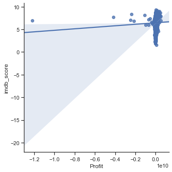

```python
sns.lmplot('Profit', 'imdb_score', data=df, fit_reg=True, height = 5);
```

```python
pf=df.groupby('Profit').size().sort_values()

pf.head()
```

```
Profit
-12213298588.000    1
13894863.000        1
13955614.000        1
13983704.000        1
14008532.000        1
dtype: int64
```

```python
pf = df[df['Profit'] != df['Profit'].min()].copy().sort_values('Profit')
pf.head(1)
```

|  | director_name | num_critic_for_reviews | duration | director_facebook_likes | actor_3_facebook_likes | actor_2_name | actor_1_facebook_likes | gross | genres | actor_1_name | movie_title | num_voted_users | cast_total_facebook_likes | actor_3_name | facenumber_in_poster | plot_keywords | num_user_for_reviews | country | content_rating | budget | title_year | actor_2_facebook_likes | imdb_score | movie_facebook_likes | Profit | Profit_Margin |
| --- | --- | --- | --- | --- | --- | --- | --- | --- | --- | --- | --- | --- | --- | --- | --- | --- | --- | --- | --- | --- | --- | --- | --- | --- | --- | --- |
| 3859 | Chan-wook Park | 202.000 | 112.000 | 0.000 | 38.000 | Yeong-ae Lee | 717.000 | 211667.000 | Crime\|Drama | Min-sik Choi | Lady Vengeance | 53508 | 907 | Hye-jeong Kang | 0.000 | cake\|christian\|lesbian sex\|oral sex\|pregnant schoolgirl | 131.000 | South Korea | R | 4200000000.000 | 2005.000 | 126.000 | 7.700 | 4000 | -4199788333.000 | -19841.488 |

```python
pf1 = pf[pf['Profit'] > -2000000].copy()
```

### IMDB Score By Profit

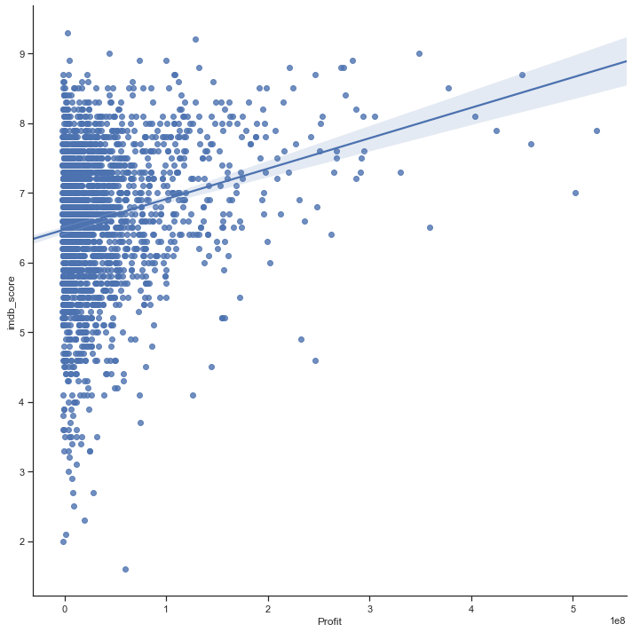

```python
sns.lmplot('Profit', 'imdb_score', data=pf1, fit_reg=True, height = 10);
```

### IMDB Score By Gross

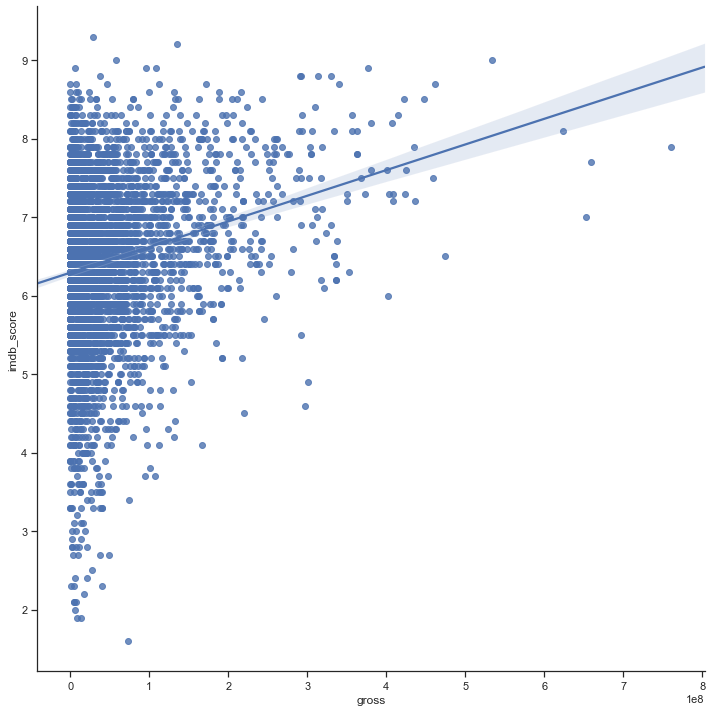

```python
sns.lmplot('gross', 'imdb_score', data=df, fit_reg=True, height = 10);
```

### IMDB Score By Duration

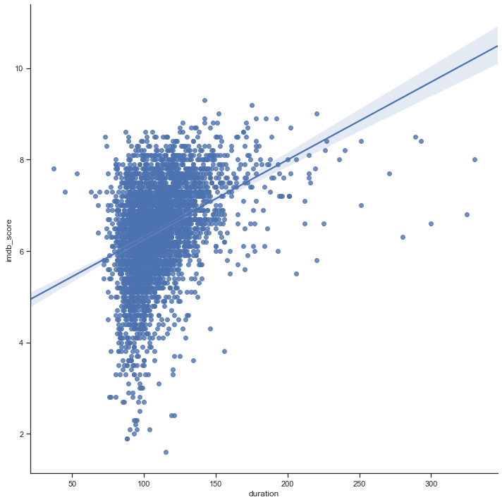

```python
sns.lmplot('duration', 'imdb_score', data=df, fit_reg=True, height = 10);
```